# Coursework Report

*N* removed NAs: 2

*N* removed typo: 1

*N* removed <18: 26

*N* total clean: 121

| Group | *N* | *M*<sub>age</sub> | *M*<sub>rating</sub> |
| --- | --- | --- | --- |
| Control | 67 | 21.04 | 6.75 |
| Experim | 54 | 20.57 | 6.29 |

**Main analysis results**

*t*(119) = 3.66, *p* < .001

[interactive chart not shown]

[figure not shown]

[interactive chart not shown]

# Coursework Report

Analysing Data, Spring 2020

# Methods

## Participants

Figure 1 *Descriptive statistics by Condition*

[output not shown]

## Design

The conceptual hypothesis for this study was to research whether colour influences attractiveness. In this study, colour was an independent categorical variable. This was operationalised by having two colours, the red, which was the experimental colour and the control which was white. The other variable was attractiveness, this was operationalised by having a rating of 1-9 on the three questions ‘ How attractive do you think this person is?’, ‘How pleasant is this person to look at?’, and ‘If I were to meet the person in this picture face to face, I would think he is attractive’. The higher the score, the more attractive that person was perceived to be, an average of these scores was measured to get a composite score. The predictor of this experiment was the colour, as this is the variable we were manipulating. Our outcome is attractiveness, which is a continuous variable. The operational hypothesis of this study is that by looking at different coloured frames around an image of a relatively somewhat attractive man, does it influence the mean ratings of his attractiveness. The statistical analysis that will be used to test this hypothesis will be a T-test, as this will analyse the composite score by the two-colour groups.

# Results

The composite score was calculated by the mean of each person’s scores on the three questions that were asked in order to judge the male’s attractiveness. This was measured by a scale rating from 1-9 (the higher the score, the higher the attractiveness). In Figure 2, we can see the mean and the standard deviation for the control and experimental group for each of the three questions. The control group had a mean rating of attractiveness of 6.75, with a standard deviation across all three questions of 1.15. The experimental group had a lower mean rating of attractiveness of 6.29, with a higher standard deviation of 1.38 across all three questions. This therefore indicates, that the control group (which had the white frame around the image) had a higher rating of attractiveness. It is also worth noting that for the question which asked, ‘If I were to meet the person in this picture face to face, I would think he is attractive’, this stimulated the highest rating of attractiveness when viewing the coloured frames.

Figure 2 Summary of Data for each Condition and Question

| Condition | Mean Question 1 | SD Question 1 | Mean Question 2 | SD Question 2 | Mean Question 3 | SD Question 3 |
| --- | --- | --- | --- | --- | --- | --- |
| control | 6.60 | 1.16 | 6.74 | 1.17 | 6.93 | 1.12 |
| experimental | 6.17 | 1.21 | 6.31 | 1.63 | 6.39 | 1.32 |

Looking at the results from our t-test, we can see that the p-value is significant, as 0.001 was the significance value that was set before the research was conducted and data analysed. By having a p<.001 shows us that it is below that significance level, and the result is statistically significant. We are therefore unlikely to find a test statistic as large as the one we found, if the null hypothesis is true, concluding that it is unlikely the two means came from the same population. In Figure 3, we can see that the control group presented a slightly higher mean rating of attractiveness, compared to the experimental group. This is in alignment from the mean ratings of attractiveness that were calculated from the t-test for the control and experimental group.

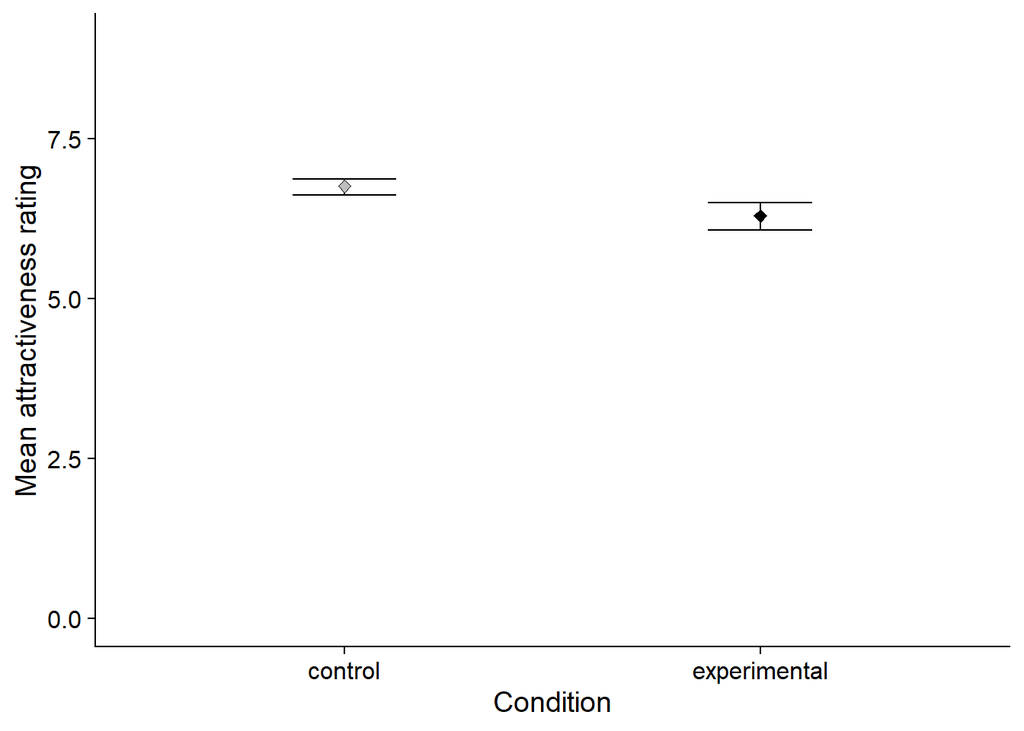

*Fig 3.* Mean Ratings of Attractiveness with the Conditions

# Discussion

The strengths of this study were that the experiment used a between-subjects colour manipulation, this meant that the participants would not see the same colour presentations continuously, which could have affected the validity of the results. Furthermore, a relative broad age range was used in this experiment, hence, a wide range of youth demographics was represented. However, the limitations of this study need to be considered. In the experiment we only looked at the frame colour, which is not generalisable to society, as normally individual’s base attractiveness ratings on the clothing that one tends to wear. Hence, future studies could look at clothing colour to increase the validity of the results. Moreover, the photos presented to the participants judging the attractiveness were the same each time, just with a different coloured frame around the image. Next time, a photo of a different man could be used to increase the validity of results, as the ratings could have been rushed if they were presented with the same individual each time.

I think this research question is worth investigating further, in order for us to gain more knowledge about this intriguing subject matter. It could prove to be important for society as a whole to find out more information if colour does influence attractiveness. Future studies could test if a women’s ovulation cycle has an impact on attractiveness ratings. Past research has shown that women tend to prefer red items prior to ovulation (Durante, Griskevicius, Hill, Perilloux & Li, 2011). Further research could be conducted to examine if women find men wearing a red item of clothing more attractive near their ovulation cycle. Furthermore, to obtain a higher validity of results, future studies could focus on introducing a heart rate monitor, alongside conducting a coloured frame experiment similar to one we conducted. The aim here being that the more attractive an individual is perceived the higher the heart rate would be. To summarise, the findings of this study is that colour does not necessarily have an impact on attractiveness ratings when focusing on frame colour. However, future studies should be conducted in order to come to a more concise conclusion.

# References

Durante, K., Griskevicius, V., Hill, S., Perilloux, C., & Li, N. (2011). Ovulation, Female Competition, and Product Choice: Hormonal Influences on Consumer Behavior. Journal Of Consumer Research, 37(6), 921-934.

Elliot, A., Niesta Kayser, D., Greitemeyer, T., Lichtenfeld, S., Gramzow, R., Maier, M., & Liu, H. (2010). Red, rank, and romance in women viewing men. Journal Of Experimental Psychology: General, 139(3), 399-417.

Francis, G. (2013). Publication bias in “Red, rank, and romance in women viewing men,” by Elliot et al. (2010). Journal Of Experimental Psychology: General, 142(1), 292-296.

Hesslinger, V., Goldbach, L., & Carbon, C. (2015). Men in red: A reexamination of the red-attractiveness effect. Psychonomic Bulletin & Review, 22(4), 1142-1148.

Peperkoorn, L., Roberts, S., & Pollet, T. (2016). Revisiting the Red Effect on Attractiveness and Sexual Receptivity. Evolutionary Psychology, 14(4), 147470491667384.

Schwarz, S., & Singer, M. (2013). Romantic red revisited: Red enhances men’s attraction to young, but not menopausal women. Journal Of Experimental Social Psychology, 49(1), 161-164.